# IMP>ACT Example CFA analyses

Author

Sven De Maeyer

# Preparation

## Loading the necessary packages

Different packages are necessary to conduct the analyses:

- `foreign` to import data from other software packages;
- `here` helps us to write links to local files in a reproducible way;
- `tidyverse` for different data-wrangling steps etc;
- `lavaan` for Structural Equation Modeling (so, also for CFA);
- `semPlot` for creating graphical representations of the models;
- `semTools` for add-on functionalities related to SEM analyses.

**Note**

If you want to use packages, make sure that you have installed them beforehand. Installing packages on you computer can be done with the command `install_packages(lavaan, dependencies = T)` for example if you want to install `lavaan`. Or you can do it in the menu under the tab Packages in the RStudio Graphic user interface. Installing packages is something you have to do once, so not every time you want to run your code. Loading the packages, on the other hand, has to be repeated if you want to do certain analyses that necessitate functions from that package. Therefore, you can find the commands `library( )` in the next code block.

```r
library(foreign)
library(here)
library(tidyverse)
library(lavaan)
library(semPlot)
library(semTools)
```

## Importing the data

The dataset provided for this example is an SPSS dataset. It is stored in the folder **Data** within the project folder. The following code imports the dataset into R.

```r
Data_IMPACT <- read.spss(
  file = here("Data", "AC.sav"),
  to.data.frame = T,
  use.value.labels = F
)
```

The `read.spss( )` function is part of the `foreign` package. Within this function we call different arguments:

- `file =` is to define the location of the file. We use the function `here( )` to make life easy as it allows you just to write down the names of the folders where the file is stored and the filename. No need to write down the full path towards the file (which is great for reproducibility).
- `to.data.frame = T` implies that data will be stored in R as a data.frame object;
- `use.value.labels = F` can be used to assure that the raw codes from categorical variables in SPSS are stored, rather than the labels (e.g., store the codes `1` and `2` rather than `Boy`and `Girl` if these are the labels given in an SPSS file).

## Data-wrangling

Often, we have to do some manipulations with the data before it is ready for analyses.

For instance, the example dataset contains some background-variables (i.e., i2-i5). To make the data more accessible we could rename and recode these variables.

My preference is to use the fabulous `dplyr` package, which is part of the `tidyverse` universe!

Let us first rename the background variables to more informative names. In the following codeblock we make use of the `rename()` function. The `head(Data_IMPACT, n = 5)` prints the first 5 rows of the dataset so we can check if the renaming is succesfull.

```r
Data_IMPACT <- Data_IMPACT %>%
  rename(
    SchoolID = i2,
    Grade = i3,
    Sex = i5)

head(Data_IMPACT, n = 5)
```

```
   ID SchoolID Grade Sex i56 i57 i58 i59 i60 i61 i62 i63 i64 i65 i66 i67
1 501        1     1   2   3   4   2   4   5   3   3   4   2   5   2   5
2 502        1     1   1   4   3   5   4   4   3   4   3   4   4   4   4
3 503        1     1   3   4   3   3   3   2   3   5   3   3   4   4   3
4 504        1     1   1   3   3   3   3   3   3   3   3   1   1   1   1
5 505        1     1   1   4   4   5   5   4   5   5   5   5   5   4   4
```

# CFA

The Confirmatory Factor Analyses can be performed making use of the `lavaan` package. In this section we describe a workflow to estimate the models.

## Define the base model

The full model for this dataset looks like this:

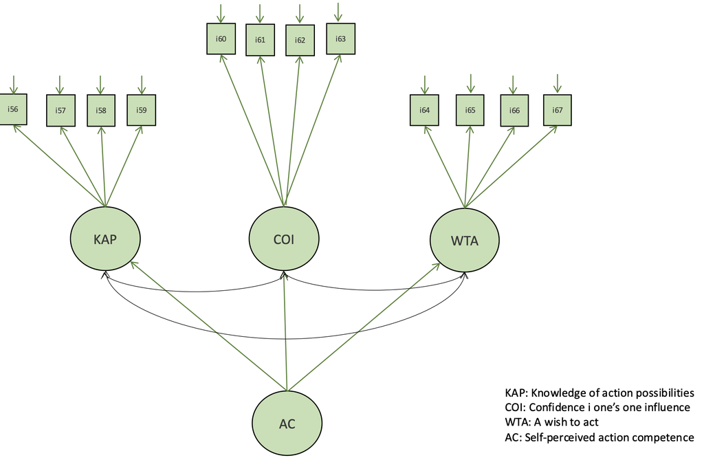

Figure 1: Full Model Definition

A first step in `lavaan` is defining the model making use of the syntax of `lavaan`. This syntax looks like the following:

- `~` is used to define a regression formula in the form of `y ~ x1 + x2` where `y` is a dependent variable and the `x1` and `x2` are explanatory variables;
- `=~` can be used to define a measurement model for a latent variable;
- `~~` is used to define a covariance between variables.

Before we estimate the full model as depicted in Figure 1, we will start with a model without the second order latent variable `AC`.

The following code defines a first basic model with three latent variables:

- `KAP` (Knowledge of Action Posibilities) measured by `i56`, `i57`, `i58`, and `i59`;
- ’COI`(Confidence in once own influence) measured by`i60`,`i61`,`i62`, and`i63`;
- `WTA` (Wish To Act) measured by `i64`, `i65`, `i66`, and `i67`.

We will call the object that stores the model definition `Model_Base`.

```r
Model_Base <- '
  KAP =~ i56 + i57 + i58 + i59
  COI =~ i60 + i61 + i62 + i63
  WTA =~ i64 + i65 + i66 + i67
  '
```

## Fit the base model

Now that we have defined the model, we can estimate the fit of the model to a certain dataset making use of the function `cfa( )`. The results of this estimation is stored in a new object called `Fit_Base_Model`.

```r
Fit_Base_Model <- cfa(
  model = Model_Base,
  data = Data_IMPACT
  )
```

```r
summary(Fit_Base_Model,
        fit.measures = T,
        standardized = T)
```

```
lavaan 0.6-19 ended normally after 32 iterations

  Estimator                                         ML
  Optimization method                           NLMINB
  Number of model parameters                        27

  Number of observations                           614

Model Test User Model:

  Test statistic                               158.081
  Degrees of freedom                                51
  P-value (Chi-square)                           0.000

Model Test Baseline Model:

  Test statistic                              3869.455
  Degrees of freedom                                66
  P-value                                        0.000

User Model versus Baseline Model:

  Comparative Fit Index (CFI)                    0.972
  Tucker-Lewis Index (TLI)                       0.964

Loglikelihood and Information Criteria:

  Loglikelihood user model (H0)              -9657.086
  Loglikelihood unrestricted model (H1)      -9578.046

  Akaike (AIC)                               19368.173
  Bayesian (BIC)                             19487.513
  Sample-size adjusted Bayesian (SABIC)      19401.793

Root Mean Square Error of Approximation:

  RMSEA                                          0.058
  90 Percent confidence interval - lower         0.048
  90 Percent confidence interval - upper         0.069
  P-value H_0: RMSEA <= 0.050                    0.084
```

[output cut: 40 more lines]

```
   .i56               0.866    0.053   16.358    0.000    0.866    0.734
   .i57               0.524    0.041   12.939    0.000    0.524    0.422
   .i58               0.362    0.032   11.280    0.000    0.362    0.349
   .i59               0.442    0.035   12.549    0.000    0.442    0.403
   .i60               0.451    0.038   11.870    0.000    0.451    0.282
   .i61               0.421    0.035   12.175    0.000    0.421    0.294
   .i62               0.571    0.041   13.979    0.000    0.571    0.383
   .i63               0.749    0.047   16.009    0.000    0.749    0.587
   .i64               0.393    0.032   12.145    0.000    0.393    0.276
   .i65               0.322    0.029   11.143    0.000    0.322    0.242
   .i66               0.590    0.040   14.650    0.000    0.590    0.410
   .i67               0.867    0.055   15.901    0.000    0.867    0.548
    KAP               0.314    0.050    6.340    0.000    1.000    1.000
    COI               1.147    0.092   12.490    0.000    1.000    1.000
    WTA               1.031    0.081   12.648    0.000    1.000    1.000
```

We can also visualise the estimated model making use of the `semPaths( )` function from the `semPlot` package.

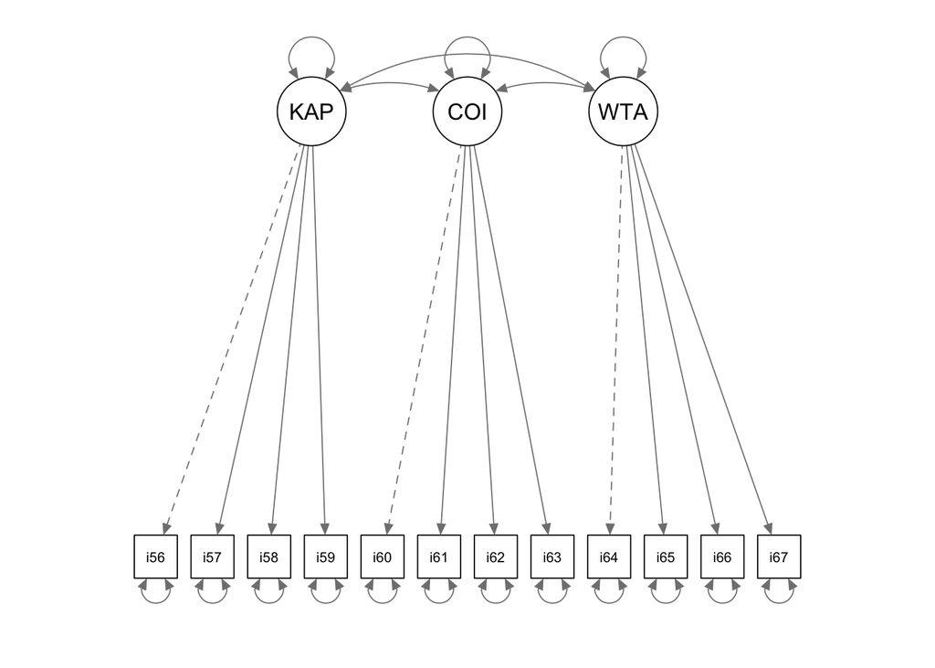

```r
semPaths(
  Fit_Base_Model,
  intercepts = F)
```

This function can be extended by using extra arguments. For instance, we can also use the `whatLabels = "std"` argument to add the standardized parameter estimates to the plot.

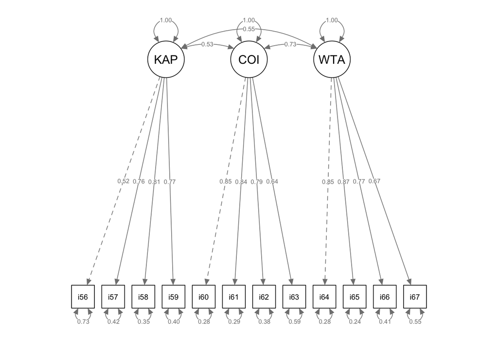

```r
semPaths(
  Fit_Base_Model,
  intercepts = F,
  whatLabels = "std")
```

Later on we will also demonstrate mutligroup analyses to evaluate the measurement invariance of instruments. The `semPlot` package allows you to visualise the results of these type of analyses as well.

## Modification indices

A typical step in CFA is scanning the modification indices when a model doesn’t fit the data well enough. To ask for modification indices in `lavaan` we can rely on the `modindices( )` function.

In the following code we ask to print the modification indices for our model, sort these modification indices according to there values (highest modification indices first) and to only print the first 10 of them (to avoid a long list of modidfication indices).

```r
modindices(Fit_Base_Model,
           sort = T,
           maximum.number = 10)
```

```
    lhs op rhs     mi    epc sepc.lv sepc.all sepc.nox
54  WTA =~ i63 22.627  0.307   0.311    0.275    0.275
47  WTA =~ i56 20.073  0.233   0.237    0.218    0.218
34  KAP =~ i63 18.311  0.383   0.214    0.190    0.190
39  COI =~ i56 17.980  0.205   0.220    0.202    0.202
119 i65 ~~ i67 17.519 -0.130  -0.130   -0.245   -0.245
61  i56 ~~ i63 16.606  0.142   0.142    0.176    0.176
115 i64 ~~ i65 15.477  0.127   0.127    0.356    0.356
90  i59 ~~ i65 14.264 -0.079  -0.079   -0.210   -0.210
116 i64 ~~ i66 12.664 -0.108  -0.108   -0.225   -0.225
120 i66 ~~ i67  9.428  0.106   0.106    0.148    0.148
```

## Adapt the base model

Imagine we want to estimate an alternative model incorporating the `WTA =~ i63` parameter in the model (regardless of it’s theoretical value). Now, the process start allover again. First we define our model, then we estimate the model, and finally we inspect the model fit.

**Note**

Notice how we incorporate all the code in one codeblock this time. That makes it more condense. To increase the readability of the code I added some inline remarks in the codeblock (the lines starting with `#`).

Also, it is always wise to give new models a new name and store the fit in a new object.

```r
# Define the adapted model

Model_Adapted <- '
  KAP =~ i56 + i57 + i58 + i59
  COI =~ i60 + i61 + i62 + i63
  WTA =~ i64 + i65 + i66 + i67 + i63
  '

# Estimate the model

Fit_Base_Adapted <- cfa(
  Model_Adapted,
  data = Data_IMPACT
)

# Evaluate model fit of the adapted model and inspect model output

summary(Fit_Base_Adapted,
        fit.measures = T,
        standardized = T)
```

```
lavaan 0.6-19 ended normally after 34 iterations

  Estimator                                         ML
  Optimization method                           NLMINB
  Number of model parameters                        28

  Number of observations                           614

Model Test User Model:

  Test statistic                               135.681
  Degrees of freedom                                50
  P-value (Chi-square)                           0.000

Model Test Baseline Model:

  Test statistic                              3869.455
  Degrees of freedom                                66
  P-value                                        0.000

User Model versus Baseline Model:

  Comparative Fit Index (CFI)                    0.977
  Tucker-Lewis Index (TLI)                       0.970

Loglikelihood and Information Criteria:

  Loglikelihood user model (H0)              -9645.886
  Loglikelihood unrestricted model (H1)      -9578.046

  Akaike (AIC)                               19347.773
  Bayesian (BIC)                             19471.533
  Sample-size adjusted Bayesian (SABIC)      19382.638

Root Mean Square Error of Approximation:

  RMSEA                                          0.053
  90 Percent confidence interval - lower         0.042
  90 Percent confidence interval - upper         0.064
  P-value H_0: RMSEA <= 0.050                    0.316
```

[output cut: 41 more lines]

```
   .i56               0.866    0.053   16.356    0.000    0.866    0.734
   .i57               0.524    0.041   12.939    0.000    0.524    0.422
   .i58               0.362    0.032   11.283    0.000    0.362    0.349
   .i59               0.442    0.035   12.555    0.000    0.442    0.403
   .i60               0.434    0.038   11.340    0.000    0.434    0.272
   .i61               0.411    0.035   11.767    0.000    0.411    0.287
   .i62               0.565    0.041   13.807    0.000    0.565    0.379
   .i63               0.743    0.045   16.507    0.000    0.743    0.581
   .i64               0.391    0.032   12.193    0.000    0.391    0.275
   .i65               0.317    0.029   11.122    0.000    0.317    0.238
   .i66               0.595    0.040   14.737    0.000    0.595    0.414
   .i67               0.875    0.055   15.955    0.000    0.875    0.552
    KAP               0.314    0.050    6.343    0.000    1.000    1.000
    COI               1.164    0.093   12.583    0.000    1.000    1.000
    WTA               1.032    0.081   12.676    0.000    1.000    1.000
```

## Compare models

When we have two (or more) competing models, we can compare them on their fit. To perform this model comparison we rely on the `anova()` function.

```r
anova(Fit_Base_Model,
      Fit_Base_Adapted)
```

```
Chi-Squared Difference Test

                 Df   AIC   BIC  Chisq Chisq diff   RMSEA Df diff Pr(>Chisq)
Fit_Base_Adapted 50 19348 19472 135.68
Fit_Base_Model   51 19368 19488 158.08       22.4 0.18669       1  2.214e-06

Fit_Base_Adapted
Fit_Base_Model   ***
---
Signif. codes:  0 '***' 0.001 '**' 0.01 '*' 0.05 '.' 0.1 ' ' 1
```

In this example we can see that there is a significant difference in model fit between the two models.

# Measurement Invariance

```r
Data_Grade2_Grade3 <- Data_IMPACT %>%
  filter(
    Grade == 2 | Grade == 3
  )

# configural invariance
fit1 <- cfa(Model_Adapted,
            data = Data_Grade2_Grade3,
            group = "Grade")

# weak invariance
fit2 <- cfa(Model_Adapted,
            data = Data_Grade2_Grade3,
            group = "Grade",
            group.equal = "loadings")

# strong invariance
fit3 <- cfa(Model_Adapted,
            data = Data_Grade2_Grade3,
            group = "Grade",
            group.equal = c("intercepts", "loadings"))

# model comparison tests
lavTestLRT(fit1, fit2, fit3)
```

```
Chi-Squared Difference Test

      Df    AIC    BIC  Chisq Chisq diff   RMSEA Df diff Pr(>Chisq)
fit1 100 6540.2 6805.7 156.34
fit2 110 6537.3 6769.6 173.43     17.090 0.08337      10    0.07241 .
fit3 119 6539.8 6742.2 193.94     20.509 0.11197       9    0.01502 *
---
Signif. codes:  0 '***' 0.001 '**' 0.01 '*' 0.05 '.' 0.1 ' ' 1
```

Another way to perform measurement invariance analyses is to rely on the function `measurementInvariance( )` from the `semTools` package. This will estimate different models in the background and compare these models. So, the output is an overview of fit indices for different models with increased equality constraints.

```r
measurementInvariance(
  model = Model_Adapted,
  data = Data_Grade2_Grade3,
  group = "Grade"
)
```

```
Measurement invariance models:

Model 1 : fit.configural
Model 2 : fit.loadings
Model 3 : fit.intercepts
Model 4 : fit.means


Chi-Squared Difference Test

                Df    AIC    BIC  Chisq Chisq diff   RMSEA Df diff Pr(>Chisq)
fit.configural 100 6540.2 6805.7 156.34
fit.loadings   110 6537.3 6769.6 173.43    17.0895 0.08337      10    0.07241 .
fit.intercepts 119 6539.8 6742.2 193.94    20.5094 0.11197       9    0.01502 *
fit.means      122 6542.3 6734.7 202.37     8.4285 0.13319       3    0.03794 *
---
Signif. codes:  0 '***' 0.001 '**' 0.01 '*' 0.05 '.' 0.1 ' ' 1


Fit measures:

                 cfi rmsea cfi.delta rmsea.delta
fit.configural 0.961 0.074        NA          NA
fit.loadings   0.956 0.075     0.005       0.001
fit.intercepts 0.948 0.079     0.008       0.003
fit.means      0.944 0.080     0.004       0.002
```